# Project: No-show appointments data analysis

- Introduction
- Data Wrangling
- Exploratory Data Analysis
- Conclusions

## 1. Introduction

This No-show appointments dataset collects information from 100k medical appointments in Brazil and is focused on the question of whether or not patients show up for their appointment. A number of characteristics about the patient are included in each row. including: • ‘ScheduledDay’ tells us on what day the patient set up their appointment. • ‘Neighborhood’ indicates the location of the hospital. • ‘Scholarship’ indicates whether or not the patient is enrolled in Brasilian welfare program Bolsa Família. (NB: the encoding of the last column: it says ‘No’ if the patient showed up to their appointment, and ‘Yes’ if they did not show up.) The questions I would like to answer with these data are: -What proportion of patients show up for their appointment? -What are the factors that are strongly correlated with patients' liklihood of whowing up at hospital? -Can we predict if a patient will show up for their scheduled appointment based on these factors?

```python
# import statements
import pandas as pd
import numpy as np
import matplotlib.pyplot as plt
import seaborn as sns
import statsmodels.api as sm
% matplotlib inline
```

## 2. Data Wrangling

### 2.1. Load data

```python
df=pd.read_csv('noshowappointments-kagglev2-may-2016.csv')
```

### 2.2. Read data

```python
df
```

|  | PatientId | AppointmentID | Gender | ScheduledDay | AppointmentDay | Age | Neighbourhood | Scholarship | Hipertension | Diabetes | Alcoholism | Handcap | SMS_received | No-show |
| --- | --- | --- | --- | --- | --- | --- | --- | --- | --- | --- | --- | --- | --- | --- |
| 0 | 2.987250e+13 | 5642903 | F | 2016-04-29T18:38:08Z | 2016-04-29T00:00:00Z | 62 | JARDIM DA PENHA | 0 | 1 | 0 | 0 | 0 | 0 | No |
| 1 | 5.589980e+14 | 5642503 | M | 2016-04-29T16:08:27Z | 2016-04-29T00:00:00Z | 56 | JARDIM DA PENHA | 0 | 0 | 0 | 0 | 0 | 0 | No |
| 2 | 4.262960e+12 | 5642549 | F | 2016-04-29T16:19:04Z | 2016-04-29T00:00:00Z | 62 | MATA DA PRAIA | 0 | 0 | 0 | 0 | 0 | 0 | No |
| 3 | 8.679510e+11 | 5642828 | F | 2016-04-29T17:29:31Z | 2016-04-29T00:00:00Z | 8 | PONTAL DE CAMBURI | 0 | 0 | 0 | 0 | 0 | 0 | No |
| 4 | 8.841190e+12 | 5642494 | F | 2016-04-29T16:07:23Z | 2016-04-29T00:00:00Z | 56 | JARDIM DA PENHA | 0 | 1 | 1 | 0 | 0 | 0 | No |
| 5 | 9.598510e+13 | 5626772 | F | 2016-04-27T08:36:51Z | 2016-04-29T00:00:00Z | 76 | REPÚBLICA | 0 | 1 | 0 | 0 | 0 | 0 | No |
| 6 | 7.336880e+14 | 5630279 | F | 2016-04-27T15:05:12Z | 2016-04-29T00:00:00Z | 23 | GOIABEIRAS | 0 | 0 | 0 | 0 | 0 | 0 | Yes |
| 7 | 3.449830e+12 | 5630575 | F | 2016-04-27T15:39:58Z | 2016-04-29T00:00:00Z | 39 | GOIABEIRAS | 0 | 0 | 0 | 0 | 0 | 0 | Yes |
| 8 | 5.639470e+13 | 5638447 | F | 2016-04-29T08:02:16Z | 2016-04-29T00:00:00Z | 21 | ANDORINHAS | 0 | 0 | 0 | 0 | 0 | 0 | No |
| 9 | 7.812460e+13 | 5629123 | F | 2016-04-27T12:48:25Z | 2016-04-29T00:00:00Z | 19 | CONQUISTA | 0 | 0 | 0 | 0 | 0 | 0 | No |
| 10 | 7.345360e+14 | 5630213 | F | 2016-04-27T14:58:11Z | 2016-04-29T00:00:00Z | 30 | NOVA PALESTINA | 0 | 0 | 0 | 0 | 0 | 0 | No |
| 11 | 7.542950e+12 | 5620163 | M | 2016-04-26T08:44:12Z | 2016-04-29T00:00:00Z | 29 | NOVA PALESTINA | 0 | 0 | 0 | 0 | 0 | 1 | Yes |
| 12 | 5.666550e+14 | 5634718 | F | 2016-04-28T11:33:51Z | 2016-04-29T00:00:00Z | 22 | NOVA PALESTINA | 1 | 0 | 0 | 0 | 0 | 0 | No |
| 13 | 9.113950e+14 | 5636249 | M | 2016-04-28T14:52:07Z | 2016-04-29T00:00:00Z | 28 | NOVA PALESTINA | 0 | 0 | 0 | 0 | 0 | 0 | No |
| 14 | 9.988470e+13 | 5633951 | F | 2016-04-28T10:06:24Z | 2016-04-29T00:00:00Z | 54 | NOVA PALESTINA | 0 | 0 | 0 | 0 | 0 | 0 | No |
| 15 | 9.994839e+10 | 5620206 | F | 2016-04-26T08:47:27Z | 2016-04-29T00:00:00Z | 15 | NOVA PALESTINA | 0 | 0 | 0 | 0 | 0 | 1 | No |
| 16 | 8.457440e+13 | 5633121 | M | 2016-04-28T08:51:47Z | 2016-04-29T00:00:00Z | 50 | NOVA PALESTINA | 0 | 0 | 0 | 0 | 0 | 0 | No |
| 17 | 1.479500e+13 | 5633460 | F | 2016-04-28T09:28:57Z | 2016-04-29T00:00:00Z | 40 | CONQUISTA | 1 | 0 | 0 | 0 | 0 | 0 | Yes |
| 18 | 1.713540e+13 | 5621836 | F | 2016-04-26T10:54:18Z | 2016-04-29T00:00:00Z | 30 | NOVA PALESTINA | 1 | 0 | 0 | 0 | 0 | 1 | No |
| 19 | 7.223290e+12 | 5640433 | F | 2016-04-29T10:43:14Z | 2016-04-29T00:00:00Z | 46 | DA PENHA | 0 | 0 | 0 | 0 | 0 | 0 | No |
| 20 | 6.222570e+14 | 5626083 | F | 2016-04-27T07:51:14Z | 2016-04-29T00:00:00Z | 30 | NOVA PALESTINA | 0 | 0 | 0 | 0 | 0 | 0 | Yes |
| 21 | 1.215480e+13 | 5628338 | F | 2016-04-27T10:50:45Z | 2016-04-29T00:00:00Z | 4 | CONQUISTA | 0 | 0 | 0 | 0 | 0 | 0 | Yes |
| 22 | 8.632300e+14 | 5616091 | M | 2016-04-25T13:29:16Z | 2016-04-29T00:00:00Z | 13 | CONQUISTA | 0 | 0 | 0 | 0 | 0 | 1 | Yes |
| 23 | 2.137540e+14 | 5634142 | F | 2016-04-28T10:27:05Z | 2016-04-29T00:00:00Z | 46 | CONQUISTA | 0 | 0 | 0 | 0 | 0 | 0 | No |
| 24 | 8.734860e+12 | 5641780 | F | 2016-04-29T14:19:19Z | 2016-04-29T00:00:00Z | 65 | TABUAZEIRO | 0 | 0 | 0 | 0 | 0 | 0 | No |
| 25 | 5.819370e+12 | 5624020 | M | 2016-04-26T15:04:17Z | 2016-04-29T00:00:00Z | 46 | CONQUISTA | 0 | 1 | 0 | 0 | 0 | 1 | No |
| 26 | 2.578785e+10 | 5641781 | F | 2016-04-29T14:19:42Z | 2016-04-29T00:00:00Z | 45 | BENTO FERREIRA | 0 | 1 | 0 | 0 | 0 | 0 | No |
| 27 | 1.215480e+13 | 5628345 | F | 2016-04-27T10:51:45Z | 2016-04-29T00:00:00Z | 4 | CONQUISTA | 0 | 0 | 0 | 0 | 0 | 0 | No |
| 28 | 5.926170e+12 | 5642400 | M | 2016-04-29T15:48:02Z | 2016-04-29T00:00:00Z | 51 | SÃO PEDRO | 0 | 0 | 0 | 0 | 0 | 0 | No |
| 29 | 1.225780e+12 | 5642186 | F | 2016-04-29T15:16:29Z | 2016-04-29T00:00:00Z | 32 | SANTA MARTHA | 0 | 0 | 0 | 0 | 0 | 0 | No |
| ... | ... | ... | ... | ... | ... | ... | ... | ... | ... | ... | ... | ... | ... | ... |
| 110497 | 7.935890e+14 | 5757745 | M | 2016-06-01T09:46:33Z | 2016-06-01T00:00:00Z | 76 | MARIA ORTIZ | 0 | 0 | 0 | 0 | 0 | 0 | No |
| 110498 | 9.433650e+13 | 5787655 | F | 2016-06-08T10:21:14Z | 2016-06-08T00:00:00Z | 59 | MARIA ORTIZ | 0 | 0 | 0 | 0 | 0 | 0 | No |
| 110499 | 8.219690e+14 | 5757697 | F | 2016-06-01T09:42:56Z | 2016-06-01T00:00:00Z | 66 | MARIA ORTIZ | 0 | 1 | 1 | 0 | 0 | 0 | No |
| 110500 | 4.434380e+14 | 5787233 | F | 2016-06-08T09:35:13Z | 2016-06-08T00:00:00Z | 59 | MARIA ORTIZ | 0 | 0 | 0 | 0 | 0 | 0 | No |
| 110501 | 4.544250e+11 | 5758133 | M | 2016-06-01T10:19:12Z | 2016-06-01T00:00:00Z | 44 | MARIA ORTIZ | 0 | 0 | 0 | 0 | 0 | 0 | No |
| 110502 | 7.316230e+14 | 5787937 | F | 2016-06-08T10:50:42Z | 2016-06-08T00:00:00Z | 22 | GOIABEIRAS | 0 | 0 | 0 | 0 | 0 | 0 | No |
| 110503 | 2.362180e+13 | 5759473 | F | 2016-06-01T13:00:36Z | 2016-06-01T00:00:00Z | 64 | SOLON BORGES | 0 | 0 | 0 | 0 | 0 | 0 | No |
| 110504 | 9.947980e+12 | 5788052 | F | 2016-06-08T11:06:21Z | 2016-06-08T00:00:00Z | 4 | MARIA ORTIZ | 0 | 0 | 0 | 0 | 0 | 0 | No |
| 110505 | 5.667340e+13 | 5758455 | F | 2016-06-01T10:45:50Z | 2016-06-01T00:00:00Z | 55 | MARIA ORTIZ | 0 | 0 | 0 | 0 | 0 | 0 | No |
| 110506 | 8.973880e+11 | 5758779 | M | 2016-06-01T11:09:20Z | 2016-06-01T00:00:00Z | 5 | MARIA ORTIZ | 0 | 0 | 0 | 0 | 0 | 0 | No |
| 110507 | 4.769460e+14 | 5786918 | F | 2016-06-08T09:04:18Z | 2016-06-08T00:00:00Z | 0 | MARIA ORTIZ | 0 | 0 | 0 | 0 | 0 | 0 | No |
| 110508 | 9.433650e+13 | 5757656 | F | 2016-06-01T09:41:00Z | 2016-06-01T00:00:00Z | 59 | MARIA ORTIZ | 0 | 0 | 0 | 0 | 0 | 0 | No |
| 110509 | 4.952970e+14 | 5786750 | M | 2016-06-08T08:50:51Z | 2016-06-08T00:00:00Z | 33 | MARIA ORTIZ | 0 | 0 | 0 | 0 | 0 | 0 | No |
| 110510 | 2.362180e+13 | 5757587 | F | 2016-06-01T09:35:48Z | 2016-06-01T00:00:00Z | 64 | SOLON BORGES | 0 | 0 | 0 | 0 | 0 | 0 | No |
| 110511 | 8.236000e+11 | 5786742 | F | 2016-06-08T08:50:20Z | 2016-06-08T00:00:00Z | 14 | MARIA ORTIZ | 0 | 0 | 0 | 0 | 0 | 0 | No |
| 110512 | 9.876250e+13 | 5786368 | F | 2016-06-08T08:20:01Z | 2016-06-08T00:00:00Z | 41 | MARIA ORTIZ | 0 | 0 | 0 | 0 | 0 | 0 | No |
| 110513 | 8.674780e+13 | 5785964 | M | 2016-06-08T07:52:55Z | 2016-06-08T00:00:00Z | 2 | ANTÔNIO HONÓRIO | 0 | 0 | 0 | 0 | 0 | 0 | No |
| 110514 | 2.695690e+12 | 5786567 | F | 2016-06-08T08:35:31Z | 2016-06-08T00:00:00Z | 58 | MARIA ORTIZ | 0 | 0 | 0 | 0 | 0 | 0 | No |
| 110515 | 6.456340e+14 | 5778621 | M | 2016-06-06T15:58:05Z | 2016-06-08T00:00:00Z | 33 | MARIA ORTIZ | 0 | 1 | 0 | 0 | 0 | 0 | Yes |
| 110516 | 6.923770e+13 | 5780205 | F | 2016-06-07T07:45:16Z | 2016-06-08T00:00:00Z | 37 | MARIA ORTIZ | 0 | 0 | 0 | 0 | 0 | 0 | Yes |
| 110517 | 5.574940e+12 | 5780122 | F | 2016-06-07T07:38:34Z | 2016-06-07T00:00:00Z | 19 | MARIA ORTIZ | 0 | 0 | 0 | 0 | 0 | 0 | No |
| 110518 | 7.263310e+13 | 5630375 | F | 2016-04-27T15:15:06Z | 2016-06-07T00:00:00Z | 50 | MARIA ORTIZ | 0 | 0 | 0 | 0 | 0 | 1 | No |
| 110519 | 6.542390e+13 | 5630447 | F | 2016-04-27T15:23:14Z | 2016-06-07T00:00:00Z | 22 | MARIA ORTIZ | 0 | 0 | 0 | 0 | 0 | 1 | No |
| 110520 | 9.969980e+14 | 5650534 | F | 2016-05-03T07:51:47Z | 2016-06-07T00:00:00Z | 42 | MARIA ORTIZ | 0 | 0 | 0 | 0 | 0 | 1 | No |
| 110521 | 3.635530e+13 | 5651072 | F | 2016-05-03T08:23:40Z | 2016-06-07T00:00:00Z | 53 | MARIA ORTIZ | 0 | 0 | 0 | 0 | 0 | 1 | No |
| 110522 | 2.572130e+12 | 5651768 | F | 2016-05-03T09:15:35Z | 2016-06-07T00:00:00Z | 56 | MARIA ORTIZ | 0 | 0 | 0 | 0 | 0 | 1 | No |
| 110523 | 3.596270e+12 | 5650093 | F | 2016-05-03T07:27:33Z | 2016-06-07T00:00:00Z | 51 | MARIA ORTIZ | 0 | 0 | 0 | 0 | 0 | 1 | No |
| 110524 | 1.557660e+13 | 5630692 | F | 2016-04-27T16:03:52Z | 2016-06-07T00:00:00Z | 21 | MARIA ORTIZ | 0 | 0 | 0 | 0 | 0 | 1 | No |
| 110525 | 9.213490e+13 | 5630323 | F | 2016-04-27T15:09:23Z | 2016-06-07T00:00:00Z | 38 | MARIA ORTIZ | 0 | 0 | 0 | 0 | 0 | 1 | No |
| 110526 | 3.775120e+14 | 5629448 | F | 2016-04-27T13:30:56Z | 2016-06-07T00:00:00Z | 54 | MARIA ORTIZ | 0 | 0 | 0 | 0 | 0 | 1 | No |

110527 rows × 14 columns

```python
df.head(10)
```

|  | PatientId | AppointmentID | Gender | ScheduledDay | AppointmentDay | Age | Neighbourhood | Scholarship | Hipertension | Diabetes | Alcoholism | Handcap | SMS_received | No-show |
| --- | --- | --- | --- | --- | --- | --- | --- | --- | --- | --- | --- | --- | --- | --- |
| 0 | 2.987250e+13 | 5642903 | F | 2016-04-29T18:38:08Z | 2016-04-29T00:00:00Z | 62 | JARDIM DA PENHA | 0 | 1 | 0 | 0 | 0 | 0 | No |
| 1 | 5.589980e+14 | 5642503 | M | 2016-04-29T16:08:27Z | 2016-04-29T00:00:00Z | 56 | JARDIM DA PENHA | 0 | 0 | 0 | 0 | 0 | 0 | No |
| 2 | 4.262960e+12 | 5642549 | F | 2016-04-29T16:19:04Z | 2016-04-29T00:00:00Z | 62 | MATA DA PRAIA | 0 | 0 | 0 | 0 | 0 | 0 | No |
| 3 | 8.679510e+11 | 5642828 | F | 2016-04-29T17:29:31Z | 2016-04-29T00:00:00Z | 8 | PONTAL DE CAMBURI | 0 | 0 | 0 | 0 | 0 | 0 | No |
| 4 | 8.841190e+12 | 5642494 | F | 2016-04-29T16:07:23Z | 2016-04-29T00:00:00Z | 56 | JARDIM DA PENHA | 0 | 1 | 1 | 0 | 0 | 0 | No |
| 5 | 9.598510e+13 | 5626772 | F | 2016-04-27T08:36:51Z | 2016-04-29T00:00:00Z | 76 | REPÚBLICA | 0 | 1 | 0 | 0 | 0 | 0 | No |
| 6 | 7.336880e+14 | 5630279 | F | 2016-04-27T15:05:12Z | 2016-04-29T00:00:00Z | 23 | GOIABEIRAS | 0 | 0 | 0 | 0 | 0 | 0 | Yes |
| 7 | 3.449830e+12 | 5630575 | F | 2016-04-27T15:39:58Z | 2016-04-29T00:00:00Z | 39 | GOIABEIRAS | 0 | 0 | 0 | 0 | 0 | 0 | Yes |
| 8 | 5.639470e+13 | 5638447 | F | 2016-04-29T08:02:16Z | 2016-04-29T00:00:00Z | 21 | ANDORINHAS | 0 | 0 | 0 | 0 | 0 | 0 | No |
| 9 | 7.812460e+13 | 5629123 | F | 2016-04-27T12:48:25Z | 2016-04-29T00:00:00Z | 19 | CONQUISTA | 0 | 0 | 0 | 0 | 0 | 0 | No |

### >Look the number of rows/records and columns/fields

```python
df.shape
```

```
(110527, 14)
```

### >Describe each field with summary statistics

```python
df.describe()
```

|  | PatientId | AppointmentID | Age | Scholarship | Hipertension | Diabetes | Alcoholism | Handcap | SMS_received |
| --- | --- | --- | --- | --- | --- | --- | --- | --- | --- |
| count | 1.105270e+05 | 1.105270e+05 | 110527.000000 | 110527.000000 | 110527.000000 | 110527.000000 | 110527.000000 | 110527.000000 | 110527.000000 |
| mean | 1.474963e+14 | 5.675305e+06 | 37.088874 | 0.098266 | 0.197246 | 0.071865 | 0.030400 | 0.022248 | 0.321026 |
| std | 2.560949e+14 | 7.129575e+04 | 23.110205 | 0.297675 | 0.397921 | 0.258265 | 0.171686 | 0.161543 | 0.466873 |
| min | 3.920000e+04 | 5.030230e+06 | -1.000000 | 0.000000 | 0.000000 | 0.000000 | 0.000000 | 0.000000 | 0.000000 |
| 25% | 4.172615e+12 | 5.640286e+06 | 18.000000 | 0.000000 | 0.000000 | 0.000000 | 0.000000 | 0.000000 | 0.000000 |
| 50% | 3.173180e+13 | 5.680573e+06 | 37.000000 | 0.000000 | 0.000000 | 0.000000 | 0.000000 | 0.000000 | 0.000000 |
| 75% | 9.439170e+13 | 5.725524e+06 | 55.000000 | 0.000000 | 0.000000 | 0.000000 | 0.000000 | 0.000000 | 1.000000 |
| max | 9.999820e+14 | 5.790484e+06 | 115.000000 | 1.000000 | 1.000000 | 1.000000 | 1.000000 | 4.000000 | 1.000000 |

### >Explore the data for missing values for each field

> As every field has all 110527 records, the data do not have missing values

```python
df.info()
```

```
<class 'pandas.core.frame.DataFrame'>
RangeIndex: 110527 entries, 0 to 110526
Data columns (total 14 columns):
PatientId         110527 non-null float64
AppointmentID     110527 non-null int64
Gender            110527 non-null object
ScheduledDay      110527 non-null object
AppointmentDay    110527 non-null object
Age               110527 non-null int64
Neighbourhood     110527 non-null object
Scholarship       110527 non-null int64
Hipertension      110527 non-null int64
Diabetes          110527 non-null int64
Alcoholism        110527 non-null int64
Handcap           110527 non-null int64
SMS_received      110527 non-null int64
No-show           110527 non-null object
dtypes: float64(1), int64(8), object(5)
memory usage: 11.8+ MB
```

### >Explore the data types for each column/field. This help to decide the appropriatnes of variables for the analysis.

```python
df.dtypes
```

```
PatientId         float64
AppointmentID       int64
Gender             object
ScheduledDay       object
AppointmentDay     object
Age                 int64
Neighbourhood      object
Scholarship         int64
Hipertension        int64
Diabetes            int64
Alcoholism          int64
Handcap             int64
SMS_received        int64
No-show            object
dtype: object
```

### 2.3. Prepare data for analysis

To answer the quesions, what factors affect patients attendance at the appointment, and develop aprediction model, I need to transform string variables in to numeric type. The outcome variable "No_show" is a binary categorical variable. So, we can use a binary logistic regression to find out the significant predictors. The regression analysis is done in two steps the first one is a multivariable logistic regression with association coeficients where the adjuted immpact of each variable is assessed. The second analysis is fiting a prediction model using classification matchine learing approach.

> In the dataset the outcome variable is given as No_show and those with response "No" are patients attended their appointment. I rename the column name to "Show_up" and replaced the values of "No" by Yes and visversa.

```python
#rename column No_show to Show_up
df.rename(columns={'No-show':'Show_up'}, inplace=True)

df.head(11)
```

|  | PatientId | AppointmentID | Gender | ScheduledDay | AppointmentDay | Age | Neighbourhood | Scholarship | Hipertension | Diabetes | Alcoholism | Handcap | SMS_received | Show_up |
| --- | --- | --- | --- | --- | --- | --- | --- | --- | --- | --- | --- | --- | --- | --- |
| 0 | 2.987250e+13 | 5642903 | F | 2016-04-29T18:38:08Z | 2016-04-29T00:00:00Z | 62 | JARDIM DA PENHA | 0 | 1 | 0 | 0 | 0 | 0 | No |
| 1 | 5.589980e+14 | 5642503 | M | 2016-04-29T16:08:27Z | 2016-04-29T00:00:00Z | 56 | JARDIM DA PENHA | 0 | 0 | 0 | 0 | 0 | 0 | No |
| 2 | 4.262960e+12 | 5642549 | F | 2016-04-29T16:19:04Z | 2016-04-29T00:00:00Z | 62 | MATA DA PRAIA | 0 | 0 | 0 | 0 | 0 | 0 | No |
| 3 | 8.679510e+11 | 5642828 | F | 2016-04-29T17:29:31Z | 2016-04-29T00:00:00Z | 8 | PONTAL DE CAMBURI | 0 | 0 | 0 | 0 | 0 | 0 | No |
| 4 | 8.841190e+12 | 5642494 | F | 2016-04-29T16:07:23Z | 2016-04-29T00:00:00Z | 56 | JARDIM DA PENHA | 0 | 1 | 1 | 0 | 0 | 0 | No |
| 5 | 9.598510e+13 | 5626772 | F | 2016-04-27T08:36:51Z | 2016-04-29T00:00:00Z | 76 | REPÚBLICA | 0 | 1 | 0 | 0 | 0 | 0 | No |
| 6 | 7.336880e+14 | 5630279 | F | 2016-04-27T15:05:12Z | 2016-04-29T00:00:00Z | 23 | GOIABEIRAS | 0 | 0 | 0 | 0 | 0 | 0 | Yes |
| 7 | 3.449830e+12 | 5630575 | F | 2016-04-27T15:39:58Z | 2016-04-29T00:00:00Z | 39 | GOIABEIRAS | 0 | 0 | 0 | 0 | 0 | 0 | Yes |
| 8 | 5.639470e+13 | 5638447 | F | 2016-04-29T08:02:16Z | 2016-04-29T00:00:00Z | 21 | ANDORINHAS | 0 | 0 | 0 | 0 | 0 | 0 | No |
| 9 | 7.812460e+13 | 5629123 | F | 2016-04-27T12:48:25Z | 2016-04-29T00:00:00Z | 19 | CONQUISTA | 0 | 0 | 0 | 0 | 0 | 0 | No |
| 10 | 7.345360e+14 | 5630213 | F | 2016-04-27T14:58:11Z | 2016-04-29T00:00:00Z | 30 | NOVA PALESTINA | 0 | 0 | 0 | 0 | 0 | 0 | No |

```python
df["Show_up"].replace({'No':'yes','Yes':'no'}, inplace=True)

df.head(11)
```

|  | PatientId | AppointmentID | Gender | ScheduledDay | AppointmentDay | Age | Neighbourhood | Scholarship | Hipertension | Diabetes | Alcoholism | Handcap | SMS_received | Show_up |
| --- | --- | --- | --- | --- | --- | --- | --- | --- | --- | --- | --- | --- | --- | --- |
| 0 | 2.987250e+13 | 5642903 | F | 2016-04-29T18:38:08Z | 2016-04-29T00:00:00Z | 62 | JARDIM DA PENHA | 0 | 1 | 0 | 0 | 0 | 0 | yes |
| 1 | 5.589980e+14 | 5642503 | M | 2016-04-29T16:08:27Z | 2016-04-29T00:00:00Z | 56 | JARDIM DA PENHA | 0 | 0 | 0 | 0 | 0 | 0 | yes |
| 2 | 4.262960e+12 | 5642549 | F | 2016-04-29T16:19:04Z | 2016-04-29T00:00:00Z | 62 | MATA DA PRAIA | 0 | 0 | 0 | 0 | 0 | 0 | yes |
| 3 | 8.679510e+11 | 5642828 | F | 2016-04-29T17:29:31Z | 2016-04-29T00:00:00Z | 8 | PONTAL DE CAMBURI | 0 | 0 | 0 | 0 | 0 | 0 | yes |
| 4 | 8.841190e+12 | 5642494 | F | 2016-04-29T16:07:23Z | 2016-04-29T00:00:00Z | 56 | JARDIM DA PENHA | 0 | 1 | 1 | 0 | 0 | 0 | yes |
| 5 | 9.598510e+13 | 5626772 | F | 2016-04-27T08:36:51Z | 2016-04-29T00:00:00Z | 76 | REPÚBLICA | 0 | 1 | 0 | 0 | 0 | 0 | yes |
| 6 | 7.336880e+14 | 5630279 | F | 2016-04-27T15:05:12Z | 2016-04-29T00:00:00Z | 23 | GOIABEIRAS | 0 | 0 | 0 | 0 | 0 | 0 | no |
| 7 | 3.449830e+12 | 5630575 | F | 2016-04-27T15:39:58Z | 2016-04-29T00:00:00Z | 39 | GOIABEIRAS | 0 | 0 | 0 | 0 | 0 | 0 | no |
| 8 | 5.639470e+13 | 5638447 | F | 2016-04-29T08:02:16Z | 2016-04-29T00:00:00Z | 21 | ANDORINHAS | 0 | 0 | 0 | 0 | 0 | 0 | yes |
| 9 | 7.812460e+13 | 5629123 | F | 2016-04-27T12:48:25Z | 2016-04-29T00:00:00Z | 19 | CONQUISTA | 0 | 0 | 0 | 0 | 0 | 0 | yes |
| 10 | 7.345360e+14 | 5630213 | F | 2016-04-27T14:58:11Z | 2016-04-29T00:00:00Z | 30 | NOVA PALESTINA | 0 | 0 | 0 | 0 | 0 | 0 | yes |

### Convert/ encode string variables to numeric

```python
from sklearn.preprocessing import LabelEncoder
```

#### Gender

```python
df['Gender'].value_counts()
```

```
F    71840
M    38687
Name: Gender, dtype: int64
```

```python
lb_Gender = LabelEncoder()
df["Gender_code"] = lb_Gender.fit_transform(df["Gender"])
df[["Gender", "Gender_code"]].head(11)
```

|  | Gender | Gender_code |
| --- | --- | --- |
| 0 | F | 0 |
| 1 | M | 1 |
| 2 | F | 0 |
| 3 | F | 0 |
| 4 | F | 0 |
| 5 | F | 0 |
| 6 | F | 0 |
| 7 | F | 0 |
| 8 | F | 0 |
| 9 | F | 0 |
| 10 | F | 0 |

#### Show_up

```python
lb_Show_up = LabelEncoder()
df["show_up_code"] = lb_Show_up.fit_transform(df["Show_up"])
df[["Show_up", "show_up_code"]].head(11)
```

|  | Show_up | show_up_code |
| --- | --- | --- |
| 0 | yes | 1 |
| 1 | yes | 1 |
| 2 | yes | 1 |
| 3 | yes | 1 |
| 4 | yes | 1 |
| 5 | yes | 1 |
| 6 | no | 0 |
| 7 | no | 0 |
| 8 | yes | 1 |
| 9 | yes | 1 |
| 10 | yes | 1 |

#### Neighbourhood

```python
lb_Neighbourhood = LabelEncoder()
df["Neighbourhood_code"] = lb_Neighbourhood.fit_transform(df["Neighbourhood"])
df[["Neighbourhood", "Neighbourhood_code"]]
```

|  | Neighbourhood | Neighbourhood_code |
| --- | --- | --- |
| 0 | JARDIM DA PENHA | 39 |
| 1 | JARDIM DA PENHA | 39 |
| 2 | MATA DA PRAIA | 45 |
| 3 | PONTAL DE CAMBURI | 54 |
| 4 | JARDIM DA PENHA | 39 |
| 5 | REPÚBLICA | 58 |
| 6 | GOIABEIRAS | 25 |
| 7 | GOIABEIRAS | 25 |
| 8 | ANDORINHAS | 1 |
| 9 | CONQUISTA | 12 |
| 10 | NOVA PALESTINA | 50 |
| 11 | NOVA PALESTINA | 50 |
| 12 | NOVA PALESTINA | 50 |
| 13 | NOVA PALESTINA | 50 |
| 14 | NOVA PALESTINA | 50 |
| 15 | NOVA PALESTINA | 50 |
| 16 | NOVA PALESTINA | 50 |
| 17 | CONQUISTA | 12 |
| 18 | NOVA PALESTINA | 50 |
| 19 | DA PENHA | 15 |
| 20 | NOVA PALESTINA | 50 |
| 21 | CONQUISTA | 12 |
| 22 | CONQUISTA | 12 |
| 23 | CONQUISTA | 12 |
| 24 | TABUAZEIRO | 78 |
| 25 | CONQUISTA | 12 |
| 26 | BENTO FERREIRA | 6 |
| 27 | CONQUISTA | 12 |
| 28 | SÃO PEDRO | 77 |
| 29 | SANTA MARTHA | 66 |
| ... | ... | ... |
| 110497 | MARIA ORTIZ | 43 |
| 110498 | MARIA ORTIZ | 43 |
| 110499 | MARIA ORTIZ | 43 |
| 110500 | MARIA ORTIZ | 43 |
| 110501 | MARIA ORTIZ | 43 |
| 110502 | GOIABEIRAS | 25 |
| 110503 | SOLON BORGES | 73 |
| 110504 | MARIA ORTIZ | 43 |
| 110505 | MARIA ORTIZ | 43 |
| 110506 | MARIA ORTIZ | 43 |
| 110507 | MARIA ORTIZ | 43 |
| 110508 | MARIA ORTIZ | 43 |
| 110509 | MARIA ORTIZ | 43 |
| 110510 | SOLON BORGES | 73 |
| 110511 | MARIA ORTIZ | 43 |
| 110512 | MARIA ORTIZ | 43 |
| 110513 | ANTÔNIO HONÓRIO | 2 |
| 110514 | MARIA ORTIZ | 43 |
| 110515 | MARIA ORTIZ | 43 |
| 110516 | MARIA ORTIZ | 43 |
| 110517 | MARIA ORTIZ | 43 |
| 110518 | MARIA ORTIZ | 43 |
| 110519 | MARIA ORTIZ | 43 |
| 110520 | MARIA ORTIZ | 43 |
| 110521 | MARIA ORTIZ | 43 |
| 110522 | MARIA ORTIZ | 43 |
| 110523 | MARIA ORTIZ | 43 |
| 110524 | MARIA ORTIZ | 43 |
| 110525 | MARIA ORTIZ | 43 |
| 110526 | MARIA ORTIZ | 43 |

110527 rows × 2 columns

#### Check data types

```python
df.dtypes
```

```
PatientId             float64
AppointmentID           int64
Gender                 object
ScheduledDay           object
AppointmentDay         object
Age                     int64
Neighbourhood          object
Scholarship             int64
Hipertension            int64
Diabetes                int64
Alcoholism              int64
Handcap                 int64
SMS_received            int64
Show_up                object
Gender_code             int64
show_up_code            int64
Neighbourhood_code      int64
dtype: object
```

# Exploratory Data Analysis

## Research Question 1: What proportion show up?

```python
df['Show_up'].value_counts()
```

```
yes    88208
no     22319
Name: Show_up, dtype: int64
```

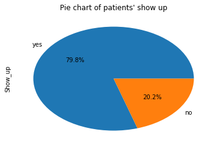

```python
df['Show_up'].value_counts().plot(kind='pie',autopct='%.1f%%',title="Pie chart of patients' show up")
```

**Finding**: From the total 110,527 patients 88,208 show up for their appointment. Thus, the proportion of patients those show up to the hospitab on their appointment was 79.8%.FiG 1

## Research Question 2.

## What factors are important for us to know in order to predict if a patient will show up for their scheduled appointment?

### Logistic regression

> Assign the independent variables (X) and the dependent variable (y)

```python
X=df[['Gender_code','Age','Neighbourhood_code','Scholarship','Hipertension','Diabetes','Alcoholism','Handcap','SMS_received']]
y=df['show_up_code']
```

> Fit the data and get a summary output with coefficients

```python
logit_model=sm.Logit(y,X)

result=logit_model.fit()

print(result.summary2())

params = result.params
conf = result.conf_int()
conf['OR'] = params
conf.columns = ['2.5%', '97.5%', 'OR']
print(np.exp(conf))
```

```
Optimization terminated successfully.
         Current function value: 0.509487
         Iterations 6
                          Results: Logit
===================================================================
Model:               Logit            Pseudo R-squared: -0.013
Dependent Variable:  show_up_code     AIC:              112642.2333
Date:                2020-01-31 04:21 BIC:              112728.7504
No. Observations:    110527           Log-Likelihood:   -56312.
Df Model:            8                LL-Null:          -55603.
Df Residuals:        110518           LLR p-value:      1.0000
Converged:           1.0000           Scale:            1.0000
No. Iterations:      6.0000
-------------------------------------------------------------------
                    Coef.  Std.Err.    z     P>|z|   [0.025  0.975]
-------------------------------------------------------------------
Gender_code         0.3708   0.0151  24.5529 0.0000  0.3412  0.4004
Age                 0.0202   0.0003  61.8919 0.0000  0.0196  0.0208
Neighbourhood_code  0.0143   0.0003  55.1926 0.0000  0.0138  0.0148
Scholarship         0.1186   0.0241   4.9185 0.0000  0.0713  0.1658
Hipertension       -0.0970   0.0248  -3.9102 0.0001 -0.1456 -0.0484
Diabetes           -0.1510   0.0346  -4.3698 0.0000 -0.2187 -0.0833
Alcoholism         -0.2345   0.0453  -5.1763 0.0000 -0.3234 -0.1457
Handcap            -0.0328   0.0491  -0.6671 0.5047 -0.1291  0.0635
SMS_received       -0.4292   0.0150 -28.6123 0.0000 -0.4586 -0.3998
===================================================================

                        2.5%     97.5%        OR
Gender_code         1.406642  1.492429  1.448901
Age                 1.019744  1.021048  1.020396
Neighbourhood_code  1.013851  1.014879  1.014365
Scholarship         1.073919  1.180341  1.125873
Hipertension        0.864545  0.952794  0.907598
Diabetes            0.803546  0.920102  0.859851
Alcoholism          0.723716  0.864384  0.790929
Handcap             0.878887  1.065594  0.967749
SMS_received        0.632165  0.670452  0.651027
```

**Interpretation of logit model output**: The liklihood of patients showing up at the hospital at the time of their appointment higher if they are male, older age, have scholarship. And having hipertention, diabetes, alcholism and reciving SMS were found to be decreasing the probability of showing up. Although these the associations of these factors with the liklihood od showing up were statitically significant, there were no strong associations as indicated by the odds ratios (OR)

# Research Question 3. Can we Predict patients show up?

Above we have seen the associations between independent variables and the outcome variable with the logit model. Now let us evaluate the pridiction capacity of our model with help of matchine learning.

### > Set the train and test split

```python
from sklearn.model_selection import train_test_split
from sklearn.linear_model import LogisticRegression
from sklearn import metrics
```

#### > Set 75% of the data train and the test will be on 25% of the data

```python
X_train,X_test,y_train,y_test=train_test_split(X,y,test_size=0.25,random_state=0)
```

### >import class

```python
from sklearn.linear_model import LogisticRegression
#intiate model
logreg = LogisticRegression()
```

### >fit the model with data

```python
logreg.fit(X_train, y_train)
```

```
LogisticRegression(C=1.0, class_weight=None, dual=False, fit_intercept=True,
          intercept_scaling=1, max_iter=100, multi_class='ovr', n_jobs=1,
          penalty='l2', random_state=None, solver='liblinear', tol=0.0001,
          verbose=0, warm_start=False)
```

### >Prediction

```python
y_pred=logreg.predict(X_test)
y_pred
```

```
array([1, 1, 1, ..., 1, 1, 1])
```

### >Model Evaluation using Confusion Matrix

```python
from sklearn import metrics
cnf_matrix = metrics.confusion_matrix(y_test, y_pred)
cnf_matrix
```

```
array([[    0,  5480],
       [    0, 22152]])
```

### >Visualizing Confusion Matrix using Heatmap

```
Text(0.5,257.44,'Predicted label')
```

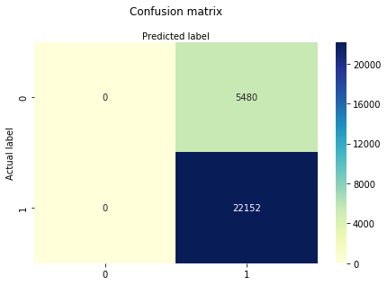

```python
class_names=[0,1] # name  of classes
fig, ax = plt.subplots()
tick_marks = np.arange(len(class_names))
plt.xticks(tick_marks, class_names)
plt.yticks(tick_marks, class_names)
# create heatmap
sns.heatmap(pd.DataFrame(cnf_matrix), annot=True, cmap="YlGnBu" ,fmt='g')
ax.xaxis.set_label_position("top")
plt.tight_layout()
plt.title('Confusion matrix', y=1.1)
plt.ylabel('Actual label')
plt.xlabel('Predicted label')
```

### >Confusion Matrix Evaluation Metrics

```python
print("Accuracy:",metrics.accuracy_score(y_test, y_pred))
print("Precision:",metrics.precision_score(y_test, y_pred))
print("Recall:",metrics.recall_score(y_test, y_pred))
```

```
Accuracy: 0.801679212507
Precision: 0.801679212507
Recall: 1.0
```

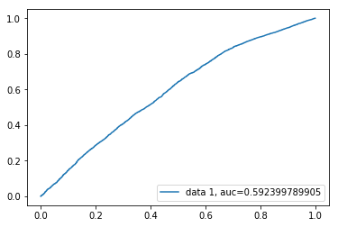

```python
#roc curve
y_pred_proba = logreg.predict_proba(X_test)[::,1]
fpr, tpr, _ = metrics.roc_curve(y_test,  y_pred_proba)
auc = metrics.roc_auc_score(y_test, y_pred_proba)
plt.plot(fpr,tpr,label="data 1, auc="+str(auc))
plt.legend(loc=4)
plt.show()
```

*Interpretation* the AUC score for the case is 0.59. AUC score 1 represents perfect classifier, and 0.5 represents a worthless classifier. Thus, our model is not a good classifier.

## Conclusions

In conclussion the proportion of patients showed up at the hospital based on their schedule was 79.8%. Although several factors have shown a statistically significant association, all of the associations were weak associations. Thus, from these dataset, we can not predict patients attendance by factors.

```python
from subprocess import call
call(['python', '-m', 'nbconvert', 'Investigate_a_Dataset.ipynb'])
```

```
0
```